# Data_replicated_assignment

Feiya Wang

12/3/2019

# **Data Replicated Assignment**

Instruction: This is the code for [Data replicated assignment](https://fuzzyatelin.github.io/bioanth-stats/data-reanalysis-assignment.html), as a individual final project. I use my dad Dr.Shaohai Wang’s paper.

Shaohai,W. Shouiqin, L. Yuanzheng, Z. *Change of Total contents of Serum Magnesium in Elderly Chinese Women with Osteoporosis*, Biological Trace Element Research. April 2005. [link to paper](https://github.com/feiyawang1207/feiyaw-data-replication-assignment/blob/master/Wang_223_231.pdf)

# 1.Introduction

Osteoporosis is a disease in which bone weakening increases the risk of a broken bone.It is the most common reason for a broken bone among the elderly.

[figure not shown]

Osteoporosis is developed as a consequence of an imbalance of mineral element metabolism in bone, such as calcium (Ca), phosphorus (P), and magnesium (Mg). Those elements are finely regulated through storage in the bone, excretion from kidney, and absorption in the intestine, among which bone exerts one of its functions to maintain Ca homeostasis by remodeling.

Postmenopausal osteoporosis of elderly women, induced presumably by both loss of estrogen and advancing age, is a serious problem for gynecoloy. Most of the research focus on Serum Calcium(sCa). Less research, however, focused on the role of Mg, another essentiaelement for bone mineralization, to bone health, even a possible role of Mg in therapy for osteoporosis. Therefore, the research goal of Dr.Wang’s paper is to explore whether the serum levels of magnesium (Mg) and calcium (Ca) differ between osteoporotic and nonosteoporotic elderly Chinese women.

# 2. Method

## 2.1 Subject

Participants for this cross-sectional analysis were recruited from a community-based population in Beijing, P. R. China, by the way of local media, poster, and health lecture between September 2002 and March 2003. To be eligible for participation, women had to be Chinese residents in Beijing and over 65 yr of age, to be ambulatory without hip replacement, and to be in good general health. The research include 324 subjects in total.

## 2.2 Measurement

### a. General body measurement

participants were requested to complete a self-made questionnaire that includes a general medical and social history, reproductive history, and menopause time.Height, weight and BMI are also measured.

### b. Bone Mineral Density (BMD) Measurements

BMD at the left femur region was assessed with posteroanterior projection, using standard techniques from dual-energy X-ray absorptiometry (Lunar Prodigy scanner, Lunar, Madison, WI).

### c. Biochemical Measurements(sCA, sMg, etc)

Overnight fasting blood and urine samples were obtained between 08:00 and 09:30 in the morning from all subjects at the same day before the questionnaire was completed.

## 2.3 Statistic analysis method

Initial data management used Foxpro 6.0 program to create a data file for each data set; the final data analysis was performed using SAS 6.12(SAS Institute, Cary, NC) on a Windows computer. The statistic methods including:

- ANOVA
- Post-hoc test using Tukey’s method
- ANCOVA–Covariate analysis
- Partial correlation test

The signifcant level is 0.05 for all the tests.

# 3. Data Analysis

## 3.1 Loading the dataset

### a. load the file

I trasfer the `.SD2` files into `.csv` file since R package can directly deal with `.ssd` or `.sas7bdat`. `.sd2`is an old version. The R help suggest that I could use SAS Sytem Viewer to export the file in `.csv` format.

```r
library (curl)
library(knitr)
#install package curl before this step to load a file from server.

f <- curl("https://raw.githubusercontent.com/feiyawang1207/feiyaw-data-replication-assignment/master/W0716.csv")
#load the file to the variable f

d <- read.csv(f, header = TRUE, sep = ",", stringsAsFactors = FALSE)
#read the .cvs file as a data frame in variable d.

kable(head(d))
```

| NUM | X101 | X102 | X103 | X104 | X105 | X106 | X107 | X108 | X109 | X110 | X111 | X112 | X113 | X201 | X202 | X203 | X204 | X204A | X205 | X206 | X2071 | X2072 | X2073 | X2074 | X2075 | X301 | X302 | X302A | X302B | … |
| --- | --- | --- | --- | --- | --- | --- | --- | --- | --- | --- | --- | --- | --- | --- | --- | --- | --- | --- | --- | --- | --- | --- | --- | --- | --- | --- | --- | --- | --- | --- |
| 2 | 08/15/35 | 149 | 54 | 1 | 3 | 3 | 2 | 1 | 1 | 1 | 40 | 4 | 2 | 3 | 1 | 1 | 0 | 0 | 2 | 2 | 1 | 4 | 1 | 1 | 1 | 15 | 1 | 29 | 6.5 | … |
| 4 | 10/15/32 | 159 | 60 | 1 | 4 | 3 | 1 | 1 | 4 | 1 | 130 | 5 | 1 | 1 | 1 | 1 | 0 | 0 | 1 | 2 | 4 | 4 | 1 | 2 | 1 | 13 | 1 | 30 | 3.0 | … |
| 5 | 10/15/36 | 150 | 44 | 1 | 3 | 3 | 2 | 1 | 1 | 2 | 90 | 5 | 2 | 2 | 1 | 1 | 0 | 0 | 2 | 3 | 2 | 4 | 1 | 4 | 1 | 12 | 1 | 40 | 7.5 | … |
| 6 | 07/15/33 | 161 | 55 | 2 | 4 | 3 | 1 | 1 | 1 | 2 | 90 | 5 | 2 | 3 | 1 | 1 | 0 | 0 | 2 | 3 | 2 | 4 | 1 | 4 | 2 | 16 | 1 | 30 | 7.0 | … |
| 7 | 06/15/37 | 156 | 57 | 1 | 3 | 3 | 1 | 1 | 1 | 1 | 80 | 5 | 2 | 4 | 1 | 1 | 0 | 0 | 2 | 2 | 4 | 4 | 2 | 1 | 1 | 15 | 2 | 90 | 7.5 | … |
| 8 | 08/15/37 | 154 | 56 | 4 | 1 | 1 | 3 | 1 | 1 | 2 | 50 | 3 | 2 | 2 | 1 | 1 | 0 | 0 | 2 | 3 | 4 | 2 | 1 | 1 | 1 | 19 | 1 | 30 | 7.5 | … |

```r
#show the top 6 rows of the data frame.
```

### b. sperate data frame from groups and check the number of subjects in each group

> Among those subjects meets the requirement, 77 were diagnosed as osteoporosis(OS), 137 participants located in osteopenic group(OC); 110 were identified as normal bone mass group(NM). The dataset have a column of OP to seperate those patients. 1 is for Osteoporosis group, 2 is osteopenic group, 3 is normal bone group.

I use `filter()` in {dplyr} package to seperate those groups

```r
library(dplyr)
OS<-filter(d, OP == 1 )
#new variable to store the data frame of only Osteoporosis people.
dim(OS)[1]
```

```
## [1] 77
```

```r
# number of subject in Osteoporosis group

OC<-filter(d, OP == 2 )
#new variable to store the data frame of only Osteopenic people.
dim(OC)[1]
```

```
## [1] 137
```

```r
# number of subject in Osteopenic group

NM<-filter(d, OP == 3 )
# new variable to store the data frame of Normal Bone Mass group
dim(NM)[1]
```

```
## [1] 110
```

```r
# number of subject in Normal Bone Mass group
```

The number of subjects in each group is consistent with the text.

## 3.2 ANOVA test

According to Table 1,2. We test some of variables ANOVA results, including age, BMI, sMg, sCa, serum phosphurs(sP), Ca*P. since those results mentions in paper text.

> There was significant difference in age, height, weight, BMI among three groups.(Wang, 2005).

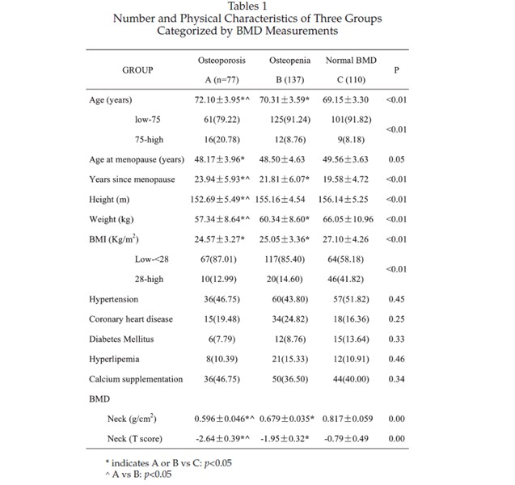

Since each group have different numbers of subject, We create a data frame that can combine the columns from those three group.

```r
Data <- data.frame(
       Y=c(OS$AGE, OC$AGE, NM$AGE),
       #combine the data of three column
       Site =factor(rep(c("OS", "OC", "NM"), times=c(length(OS$AGE), length(OC$AGE), length(NM$AGE)))
       ))

head(Data)
```

```
##          Y Site
## 1 67.42466   OS
## 2 69.50959   OS
## 3 65.42192   OS
## 4 71.76164   OS
## 5 77.01096   OS
## 6 69.50959   OS
```

With this data frame, we can apply Anova test for Age as an example.

```r
fm <- aov(Y~Site, data=Data)
result_age<- anova(fm)
result_age
```

```
## Analysis of Variance Table
##
## Response: Y
##            Df Sum Sq Mean Sq F value    Pr(>F)
## Site        2  397.0 198.481  15.444 3.948e-07 ***
## Residuals 321 4125.5  12.852
## ---
## Signif. codes:  0 '***' 0.001 '**' 0.01 '*' 0.05 '.' 0.1 ' ' 1
```

Therefore, the p value is

```r
result_age["Pr(>F)"][[1]][1]
```

```
## [1] 3.947755e-07
```

We can also view the result by Boxplot.

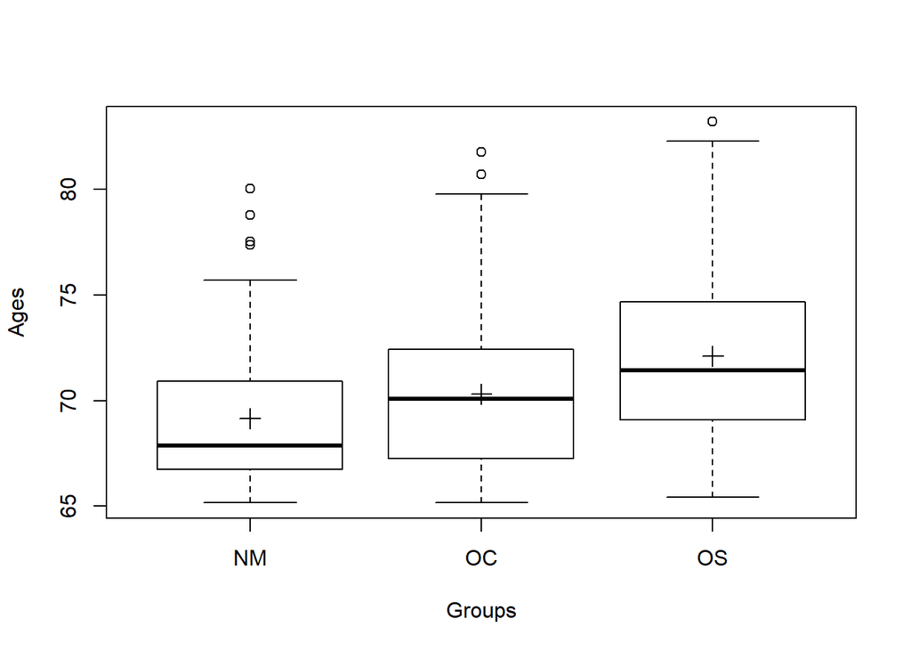

```r
plot(data = Data, Y ~ Site,xlab="Groups", ylab="Ages")  # boxplot with medians
means <- summarise(group_by(Data, Site), mean(Y))  # calculate average by group
points(1:3, means$`mean(Y)`, pch = 3, cex = 1.5)
```

We can write a function Anovatest() to produce the Anova test for other variables.

```r
Anovatest<-function(x1,x2,x3){
  # fucntion for anova for three group
  Data <- data.frame(
       Y=c(x1, x2, x3),
       #combine the data of three column
       Site =factor(rep(c("OS", "OC", "NM"), times=c(length(x1), length(x2), length(x3)))
       ))

fm <- aov(Y~Site, data=Data)
anova(fm)

}

x<-Anovatest(OS$AGE,OC$AGE,NM$AGE)
#get the Anova test results

x
```

```
## Analysis of Variance Table
##
## Response: Y
##            Df Sum Sq Mean Sq F value    Pr(>F)
## Site        2  397.0 198.481  15.444 3.948e-07 ***
## Residuals 321 4125.5  12.852
## ---
## Signif. codes:  0 '***' 0.001 '**' 0.01 '*' 0.05 '.' 0.1 ' ' 1
```

```r
p<-x["Pr(>F)"][[1]][1]
p
```

```
## [1] 3.947755e-07
```

```r
# p value
```

Therefore, for BMI, we have:

```r
x1<-Anovatest(OS$BMI,OC$BMI,NM$BMI)
#BMI
x1
```

```
## Analysis of Variance Table
##
## Response: Y
##            Df Sum Sq Mean Sq F value    Pr(>F)
## Site        2  369.3 184.671  13.702 1.949e-06 ***
## Residuals 321 4326.4  13.478
## ---
## Signif. codes:  0 '***' 0.001 '**' 0.01 '*' 0.05 '.' 0.1 ' ' 1
```

```r
#anova summary
x1
```

```
## Analysis of Variance Table
##
## Response: Y
##            Df Sum Sq Mean Sq F value    Pr(>F)
## Site        2  369.3 184.671  13.702 1.949e-06 ***
## Residuals 321 4326.4  13.478
## ---
## Signif. codes:  0 '***' 0.001 '**' 0.01 '*' 0.05 '.' 0.1 ' ' 1
```

```r
p1<-x1["Pr(>F)"][[1]][1]
#store p value
p1
```

```
## [1] 1.948868e-06
```

Since both p values is less than 0.05, the ages and BMI among different group do have significant difference.

For sMg, sCa, sP, and Ca*p, the paper mentions

> sMg level in OP group (0.91±0.11 mmol/L) was significantly higher than in the osteopenia (0.88±0.09 mmol/L) and normal (0.87±0.08 mmol/L) groups (p=0.02). In addition, the level of the product of calcium and phosphorus was lower in OP group but did not reach statistical significance (p=0.06). Interestingly, the total serum level of both Ca and Mg, the two bivalent cations, is very similar among three groups.(Wang,2005)

we can produce ANOVA for them as well.

```r
x2<-Anovatest(OS$MAGNESIU,OC$MAGNESIU,NM$MAGNESIU)
#sMg
x3<-Anovatest(OS$CALCIUM,OC$CALCIUM,NM$CALCIUM)
#sCa
x4<-Anovatest(OS$PHOSPHOR,OC$PHOSPHOR,NM$PHOSPHOR)
#sP
x5<-Anovatest(OS$PHOSPHOR*OS$CALCIUM,OC$PHOSPHOR*OC$CALCIUM,NM$PHOSPHOR*NM$CALCIUM)
#Ca*p

x2 #sMg ANOVA result
```

```
## Analysis of Variance Table
##
## Response: Y
##            Df  Sum Sq   Mean Sq F value  Pr(>F)
## Site        2 0.06322 0.0316105  3.7912 0.02359 *
## Residuals 321 2.67644 0.0083378
## ---
## Signif. codes:  0 '***' 0.001 '**' 0.01 '*' 0.05 '.' 0.1 ' ' 1
```

```r
x3 #sCa ANOVA result
```

```
## Analysis of Variance Table
##
## Response: Y
##            Df  Sum Sq   Mean Sq F value Pr(>F)
## Site        2 0.03293 0.0164652  1.7717 0.1717
## Residuals 321 2.98321 0.0092935
```

```r
x4 #sP ANOVA result
```

```
## Analysis of Variance Table
##
## Response: Y
##            Df Sum Sq  Mean Sq F value Pr(>F)
## Site        2 0.0665 0.033227   1.773 0.1715
## Residuals 321 6.0158 0.018741
```

```r
x5 #Ca*P ANOVA result
```

```
## Analysis of Variance Table
##
## Response: Y
##            Df Sum Sq Mean Sq F value  Pr(>F)
## Site        2  0.756 0.37803  2.8208 0.06104 .
## Residuals 321 43.019 0.13402
## ---
## Signif. codes:  0 '***' 0.001 '**' 0.01 '*' 0.05 '.' 0.1 ' ' 1
```

For p values:

```r
p2<-x2["Pr(>F)"][[1]][1]
p3<-x3["Pr(>F)"][[1]][1]
p4<-x4["Pr(>F)"][[1]][1]
p5<-x5["Pr(>F)"][[1]][1]
# extract p values from previous report.
table1<-cbind(p2,p3,p4,p5)
#create table for p values
colnames(table1)<-c("sMg","sCa","sP","Ca*P")
#name cloumn
rownames(table1)<-"p values"
kable(table1)
```

|  | sMg | sCa | sP | Ca*P |
| --- | --- | --- | --- | --- |
| p values | 0.0235851 | 0.1717029 | 0.1714869 | 0.0610365 |

According to table 1 and its text, the p values are all matched to table and the conclusion is consistent in paper as well.

## 3.3 post-hoc test using Tukey’s method

Once we hvae significant results from ANova, the next step is to conduct post-hoc test to determine which two or more groups in previous ANOVA test have siginificant diiference.

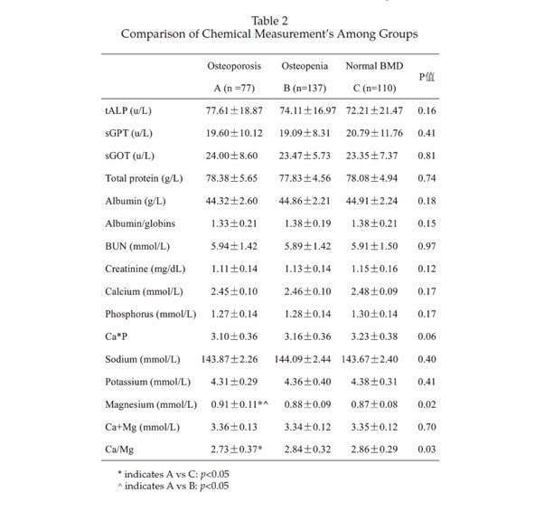

```r
Data1 <- data.frame(
       Y=c(OS$MAGNESIU, OC$MAGNESIU, NM$MAGNESIU),
       Site =factor(rep(c("OS", "OC", "NM"), times=c(length(OS$MAGNESIU), length(OC$MAGNESIU), length(NM$MAGNESIU)))
       ))
# create data frame like previous

fm <- aov(Y~Site, data=Data)
# make it into aov format so TUKEYHSD can apply on.

TUKEY1 <- TukeyHSD(x=fm, 'Site', conf.level=0.95)
#Conduct Tukey's Method

TUKEY1
```

```
##   Tukey multiple comparisons of means
##     95% family-wise confidence level
##
## Fit: aov(formula = Y ~ Site, data = Data)
##
## $Site
##           diff        lwr      upr     p adj
## OC-NM 1.168353 0.08765982 2.249047 0.0304913
## OS-NM 2.959673 1.70540623 4.213939 0.0000002
## OS-OC 1.791319 0.58902182 2.993617 0.0014922
```

A boxplot can also gives a hint of which two group can have difference:

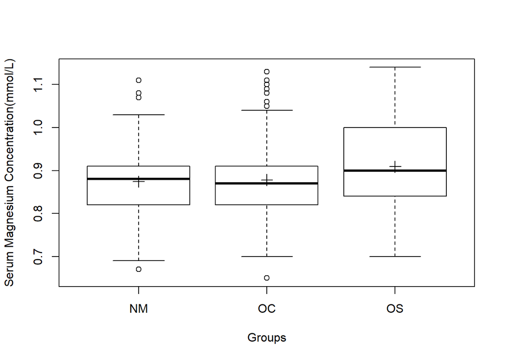

```r
plot(data = Data1, Y ~ Site,xlab="Groups", ylab="Serum Magnesium Concentration(mmol/L)")  # boxplot with medians
means <- summarise(group_by(Data1, Site), mean(Y))  # calculate average by group
points(1:3, means$`mean(Y)`, pch = 3, cex = 1.5)
```

For Ca/Mg, we also apply the Tukey Method

```r
Data2 <- data.frame(
       Y=c(OS$CALCIUM/OS$MAGNESIU,OC$CALCIUM/OC$MAGNESIU, NM$CALCIUM/NM$MAGNESIU),
       Site =factor(rep(c("OS", "OC", "NM"), times=c(length(OS$MAGNESIU), length(OC$MAGNESIU), length(NM$MAGNESIU)))
       ))
#create data frame like previous

fm2 <- aov(Y~Site, data=Data2)
# make it into aov format so TUKEYHSD can apply on.

TUKEY2 <- TukeyHSD(x=fm2, 'Site', conf.level=0.95)
#Conduct Tukey's Method

TUKEY2
```

```
##   Tukey multiple comparisons of means
##     95% family-wise confidence level
##
## Fit: aov(formula = Y ~ Site, data = Data2)
##
## $Site
##              diff        lwr          upr     p adj
## OC-NM -0.01852254 -0.1155735  0.078528408 0.8947096
## OS-NM -0.12043901 -0.2330776 -0.007800465 0.0328511
## OS-OC -0.10191647 -0.2098880  0.006055039 0.0689254
```

It shows 0.032 for OS-NM, p values are less than 0.05.Other p values are larger than 0.05. It proves that there are significant difference of Ca/Mg between OS group with NM group only, which matches the table annotation.

We could draw a boxplot as well.

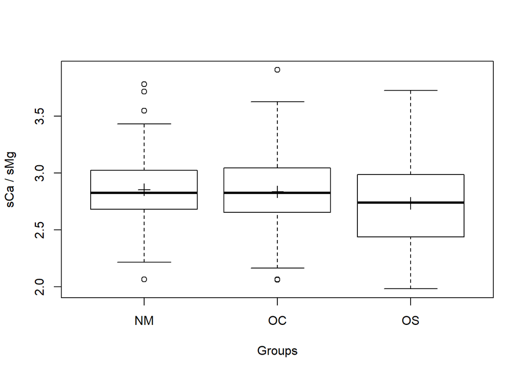

```r
plot(data = Data2, Y ~ Site,xlab="Groups", ylab="sCa / sMg")  # boxplot with medians
means <- summarise(group_by(Data2, Site), mean(Y))  # calculate average by group
points(1:3, means$`mean(Y)`, pch = 3, cex = 1.5)
```

Therefore, this part of conlcusion matches the paper’s text.

## 3.4 ANCOVA

In paper, it said:

> Covariate analysis, in which sMg value was taken as the dependent variable, revealed a significant relationship between sMg and sCa(Wang, 2005).

Therefore, we are applying ANCOVA use sCa as the predictor variable(Indepedent) and sMg as the response variable(Dependent). We will use `Anova()` in {car} package to produce ANCOVA test.

First, we will make a new data frame for ANCOVA

```r
data3 <- cbind(d$OP,d$CALCIUM,d$MAGNESIU,d$AGE,d$BMI)
# create a new data frame with all the data we need

colnames(data3)<-c("OP","CALCIUM","MAGNESIU","AGE","BMI")
# name the columns

data3<-as.data.frame(data3)
# make sure the variable is in data.frame format.

data3$OP<-as.factor(data3$OP)
# group is a level of 1,2,3 instead of numeric value, make them as factor
```

We want to check the data to see if they are normal distributed.

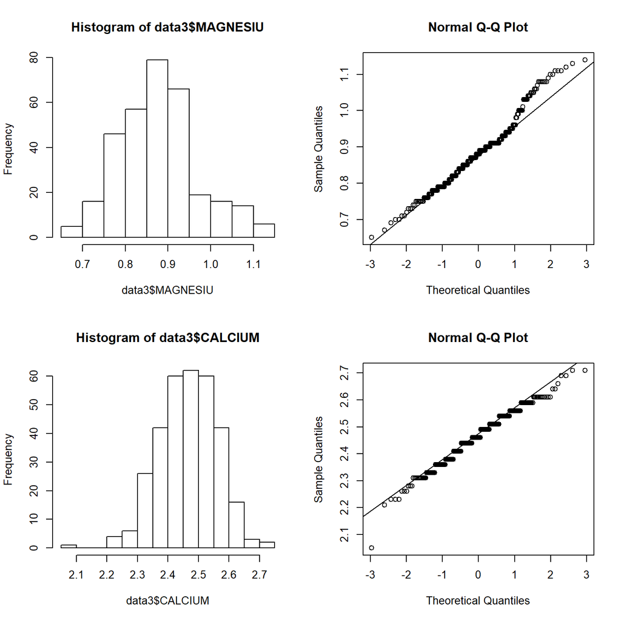

```r
par(mfrow=c(2,2))
#set a panel of 2 rows and 2 columns
hist(data3$MAGNESIU)
qqnorm(data3$MAGNESIU)
qqline(data3$MAGNESIU)
hist(data3$CALCIUM)
qqnorm(data3$CALCIUM)
qqline(data3$CALCIUM)
```

As you can see, the sMg and sCa are not normally distributed. Therefore, we use log() to make them more normally distributed for the ANCOVA test.

> When age and BMI were taken into account as covariates, the model still showed statistical significance among each group (F=3.80, p=0.024), but not age (F=0.26, p=0.612) or BMI (F=2.19, p=0.140).

```r
library(car)
# need this package for ANCOVA fucntion

m2 <- lm(data = data3, log(MAGNESIU)~ AGE*BMI+OP)

car::Anova(m2,type="2")
```

```
## Anova Table (Type II tests)
##
## Response: log(MAGNESIU)
##           Sum Sq  Df F value    Pr(>F)
## AGE       0.0032   1  0.3180 0.5732065
## BMI       0.0214   1  2.1185 0.1465176
## OP        0.0651   2  3.2204 0.0412443 *
## AGE:BMI   0.1285   1 12.7222 0.0004169 ***
## Residuals 3.2122 318
## ---
## Signif. codes:  0 '***' 0.001 '**' 0.01 '*' 0.05 '.' 0.1 ' ' 1
```

Although the F score do have a slightly difference, the p-values are similar in text and the significant results are not change as well.

> When sCa level was also considered, the difference of sMg was not significant among groups (F=2.09, p=0.126), age (F=0.23, p=0.636), and BMI(F=2.29, p=0.131), while sCa showed significance (F=8.23, p=0.004).

```r
m3 <- lm(data = data3, log(MAGNESIU)~ AGE*BMI+OP+ CALCIUM)
car::Anova(m3,type="2")
```

```
## Anova Table (Type II tests)
##
## Response: log(MAGNESIU)
##            Sum Sq  Df F value    Pr(>F)
## AGE       0.00181   1  0.1835 0.6686892
## BMI       0.02191   1  2.2243 0.1368530
## OP        0.05559   2  2.8215 0.0610095 .
## CALCIUM   0.08920   1  9.0539 0.0028315 **
## AGE:BMI   0.13884   1 14.0934 0.0002069 ***
## Residuals 3.12300 317
## ---
## Signif. codes:  0 '***' 0.001 '**' 0.01 '*' 0.05 '.' 0.1 ' ' 1
```

F scores are also slightly shifts, but the pattern is similar. and p values and significants match with the paper.

## 3.5 Partial correlation

> In the overall group, correlation studies revealed a significant negative correlation between sMg and sCa (r=–0.166, p=0.003), and when stratifying by group, only correlation between sMg and sCa in patients with osteoporosis was statistically significant (r=–0.240, p=0.038).

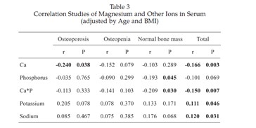

Since the text mentions the first row’s results of sCa’s correlation with groups, sMg and Age*BMI, we will focus on replicate the first row of table 3.

We use `pcor.test()` in {ppcor} package for partial correlation test

```r
library(ppcor)
c1<-pcor.test(OS$CALCIUM, OS$MAGNESIU, OS$AGE*OS$BMI)
c2<-pcor.test(OC$CALCIUM, OC$MAGNESIU, OC$AGE*OC$BMI)
c3<-pcor.test(NM$CALCIUM, NM$MAGNESIU, NM$AGE*NM$BMI)
c4<-pcor.test(d$CALCIUM, d$MAGNESIU, d$AGE*d$BMI)

c<-rbind(c1,c2,c3,c4)
c<-c[1:2]
colnames(c)<-c("r scores","p values")
rownames(c)<-c("OS","OC","NM","Total")

kable(c)
```

|  | r scores | p values |
| --- | --- | --- |
| OS | -0.2405198 | 0.0363597 |
| OC | -0.1548981 | 0.0717632 |
| NM | -0.1024627 | 0.2890527 |
| Total | -0.1720473 | 0.0019141 |

Compared to the table 3, our results onlt slightly differ in 3 decimal place on r score. The p values are almost same and the signifcant results are the same as the paper states.

# 4. Conclusion

The paper’s conclusion is that

> High content of sMg and potentially low content of sCa could be a feature of the serum profile of elderly Chinese women with OP, the clinical significance of which needs further elucidation. Supplementation of Mg for elderly Chinese women with OP did not appear to be necessary (Wang et al, 2005).

According to our replicate statistic tests, the statistic in this paper is accurate, match to their original data set.

For the different F scores in ANCOVA, the data of sMg and sCa are not normally distributed. we use log() but the authors may use different methods to make the data normally distributed. Also, the ANCOVA have different types, the authors may use different type of algorithm for ANCOVA. It may also because that author use other models(we use linear model in replicated assignment). Since it is 14 years ago, the author(my father) cannnot recall the memory of doing statistic.

For the slight different in Partial Correlation, the reason may because thepaper use SAS software to analysis all the statistic test. The Algorithm between R and SAS might have slightly difference. Also, the paper didn’t states which model and which type of partial correlation test they use, which can also cause the difference in our results.